# 34. Survival Analysis

Masahiko Asano

2025-08-23

- The R packages used here are as follows

```r
library(tidyverse)
library(survival)
library(survminer)
library(stargazer)
library(corrplot)
library(jtools)
library(margins)
library(ROCR)
library(patchwork)
library(prediction)
```

# 1. What is Survival Analysis?

- Also called time-to-event analysis
- A branch of statistics that analyzes the expected duration until an event occurs, such as biological death or machine system failure.
- Different disciplines use different terminology:

| Engineering | Reliability Analysis |
| --- | --- |
| Economics | Duration Analysis |
| Sociology | Event History Analysis |

## 1.1 What Survival Analysis Can Tell Us

- What proportion of people survive beyond a certain point in time
- Among survivors, what proportion eventually die (or experience system failure)
- Whether multiple causes of death or failure can be accounted for
- How specific conditions or characteristics increase (or decrease) the probability of survival

## 1.2 Survival Analysis Methods by Purpose

#### Example: Medical Studies

| **Research Question** | **Appropriate Method** | **Overview** |
| --- | --- | --- |
| Overall trends in treatment duration | Kaplan–Meier (KM) Survival Curve | Visualizes the number of patients surviving until the end of treatment using survival curves. |
| Differences in mortality rates between men and women | Log-rank Test | Tests whether survival curves differ statistically across two or more groups. |
| Impact of factors such as age on mortality | Cox Proportional Hazards Model | Allows simultaneous analysis of factors affecting the hazard (risk of death). |
| Significance of explanatory variables in the Cox model | Likelihood Ratio Test | Evaluates the significance of Cox regression coefficients. The likelihood ratio test assesses the overall model, while the Wald test examines the effect of each variable individually. |

## 1.3 Common Terminology in Survival Analysis

| Event | Death, onset of disease, relapse, recovery, or any other outcome of interest |
| --- | --- |
| Time | The duration from the start of observation (e.g., surgery or treatment) until (i) the occurrence of the event, (ii) the end of the study, or (iii) loss to follow-up/withdrawal from the study |
| Censoring | Occurs when some information on survival time is available, but the exact survival time is unknown |
| Survival Function: S(t) | The probability that a subject survives longer than time t |

## 1.4 Data

- Here, we use the Acute Myelogenous Leukemia (AML) survival dataset included in the survival package in R.

```r
library(survival)
```

- The survival package includes [`aml.csv`](https://github.com/asanoucla/aml.csv)
- This is the Acute Myelogenous Leukemia survival dataset
- Load the `aml.csv` data

```r
aml <- read_csv("data/aml.csv")
```

- Check the variables included in the `aml` dataset

```r
DT::datatable(aml)
```

|  | time | status | x |
| --- | --- | --- | --- |
| 1 | 9 | 1 | Maintained |
| 2 | 13 | 1 | Maintained |
| 3 | 13 | 0 | Maintained |
| 4 | 18 | 1 | Maintained |
| 5 | 23 | 1 | Maintained |
| 6 | 28 | 0 | Maintained |
| 7 | 31 | 1 | Maintained |
| 8 | 34 | 1 | Maintained |
| 9 | 45 | 0 | Maintained |
| 10 | 48 | 1 | Maintained |

[output cut: 13 more lines]

| time | Survival time or censoring time (weeks) |
| --- | --- |
| status | Cancer relapse: 0 = no event (censored), 1 = event occurred (relapse) |
| x | Treatment group: Nonmaintained (no maintenance chemotherapy), Maintained (with maintenance chemotherapy) |

##### Patient No. 12 (time = 5, status = 1)

- The patient with the shortest survival time (5 weeks)
- This patient was observed up to the 5th week (time = 5)
- The patient experienced a cancer relapse (status = 1)

##### Patient No. 11 (time = 161, status = 0)

- The patient with the longest survival time (161 weeks)
- This patient was observed up to the 161st week (time = 161)
- The patient’s data was censored (status = 0)
- Censoring here means that the patient did not experience the event (no relapse of AML)

##### Patient No. 2 (time = 13, status = 1)

- This patient was observed up to the 13th week (time = 13)
- The patient experienced a cancer relapse (status = 1)

##### Patient No. 3 (time = 13, status = 0)

- This patient was observed up to the 13th week (time = 13)
- The patient’s data was censored (status = 0)
- This means the patient did not experience a relapse up to week 13
- However, the patient was only observed for 13 weeks
- Possible reasons:  
  ・The patient joined late in the study, so only 13 weeks of data were available, or  
  ・The patient enrolled early but was lost to follow-up or withdrew from the study

#### Research Question

Whether patients who received maintenance therapy experienced a delayed relapse compared to those who did not.

## 1.5 Kaplan–Meier Survival Curve

- The survival function S(t) represents the probability that a subject survives longer than time t.
- Although S(t) is theoretically a smooth curve, in practice it is usually estimated using the Kaplan–Meier (KM) curve.

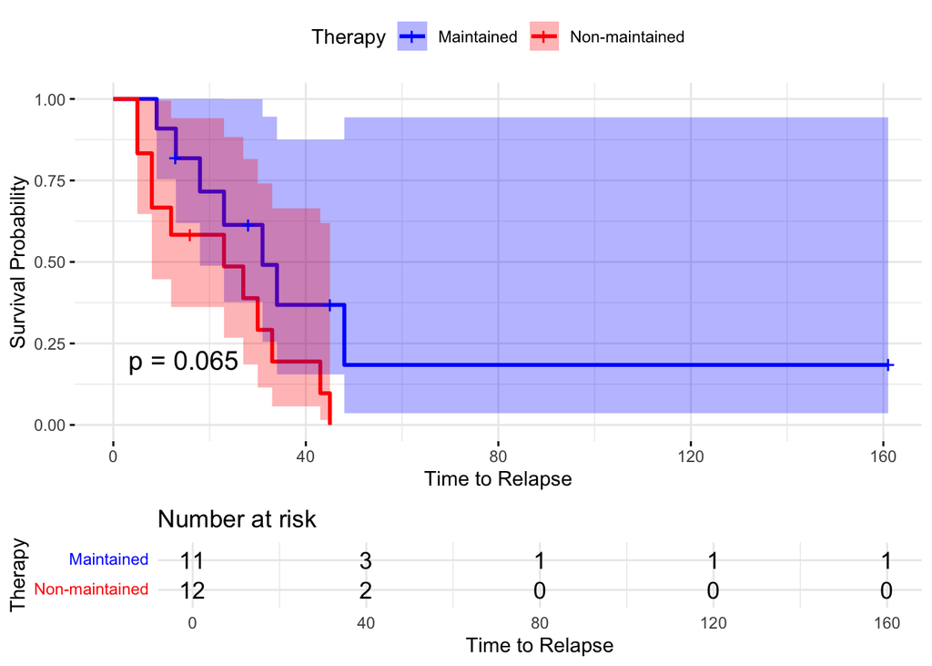

```r
library(survival)
library(survminer)

# Load data
aml <- read_csv("data/aml.csv")  # Load the uploaded aml.csv file

# Create survival object
# Time to relapse: time, Event occurrence: status, Treatment: x (Maintained or Nonmaintained)
fit <- survfit(Surv(time, status) ~ x, data = aml)

# Plot KM curve
km_1 <- ggsurvplot(fit, data = aml,
           pval = TRUE,              # p-value (log-rank test)
           conf.int = TRUE,          # Show confidence interval
           risk.table = TRUE,        # Show risk table
           xlab = "Time to Relapse",
           ylab = "Survival Probability",
           legend.title = "Therapy",
           legend.labs = c("Maintained", "Non-maintained"),
           palette = c("blue", "red"),
           ggtheme = theme_minimal())
km_1
```

#### Key Points for Interpreting the Results

- The higher a KM curve is, the greater the proportion remaining relapse-free.
- If the blue line (Maintained) lies above the red line (Non-maintained), maintenance therapy may be delaying relapse.
- If the log-rank test yields p-value < 0.05, the difference between treatment groups is statistically significant.

#### Interpreting the Plot

- The x-axis shows time from 0 (start of observation) to the last observed time.
- The y-axis shows the proportion of subjects who have not experienced the event (i.e., are still relapse-free).
- At time zero, 100% of subjects are event-free (no relapses yet).
- The stepwise solid lines (blue and red) track the occurrence of events over time.
- Blue represents “maintenance chemotherapy = yes (Maintained).”
- Red represents “maintenance chemotherapy = no (Non-maintained).”
- Vertical drops indicate an event occurred.
- Two events at week 5 ⇒ first drop ↓
- Two events at week 8 ⇒ second drop ↓
- One event at week 9 ⇒ third drop ↓
- A “+” where it intersects a horizontal segment indicates a patient was censored at that time.  
  **+ at week 13 (blue) … a censored patient in the Maintained group**  
  **+ at week 16 (red) … a censored patient in the Non-maintained group**
- As time passes, the curves trend downward to the right  
  ⇒ survival probability decreases  
  ⇒ the Non-maintained group declines more steeply  
  ⇒ the Maintained group maintains a higher survival probability.
- In the `aml` dataset, five subjects were censored at weeks 13, 16, 28, 45, and 161, respectively.
- In the KM survival curve, there are five tick marks corresponding to these censored observations.

## 1.6 Log-rank Test

```r
survdiff(Surv(time, status) ~ x, data = aml)
```

```
Call:
survdiff(formula = Surv(time, status) ~ x, data = aml)

                 N Observed Expected (O-E)^2/E (O-E)^2/V
x=Maintained    11        7    10.69      1.27       3.4
x=Nonmaintained 12       11     7.31      1.86       3.4

 Chisq= 3.4  on 1 degrees of freedom, p= 0.07
```

- Results:

[output not shown]

##### x = Maintained Group (with maintenance therapy)

- The expected number of relapses was 10.69, but in reality only 7 relapses occurred.  
  → Fewer relapses (7) than expected were observed.  
  ⇒ This suggests a possible treatment effect.

##### x = Non-maintained Group (without maintenance therapy)

- The expected number of relapses was 7.31, but in reality 11 relapses occurred.
- More relapses (11) than expected were observed.

##### Now, the result is…

Log-rank Test Result ・`p-value = 0.07` is slightly above the 0.05 significance level, and therefore not statistically significant.  
⇒ **There is some indication that patients receiving maintenance therapy experience delayed relapse, but this cannot be stated with statistical certainty.**

**Note:**

- The sample size of 23 subjects is too small.  
  ⇒ The test has very little power to detect differences between treatment groups.  
  ⇒ The chi-squared test is based on asymptotic approximation.  
  ⇒ With small sample sizes, the p-value must be interpreted with caution.
- For example, suppose we want to know:  
  Even after accounting for age and gender, do patients receiving maintenance therapy tend to relapse later?
- However, the KM method can only handle one variable (grouping factor).  
  ⇒ Multivariable analysis is not possible with KM.

#### Solution ⇒ Use the Cox Proportional Hazards Model

### Differences Between the Kaplan–Meier Method and the Cox Proportional Hazards Model

| **What you want** | **Why KM Is Insufficient** | **Why Use the Cox Model** |
| --- | --- | --- |
| 🔸 Analyze multiple factors (covariates) simultaneously | Can only handle one variable | Allows multivariable analysis |
| 🔸 Include quantitative variables | Can only handle categorical variables | Can handle continuous variables |
| 🔸 Control for confounders (e.g., gender, age) | Cannot adjust for them | The Can adjust for confounders |
| 🔸 Know the hazard ratio (risk magnitude) | Provides only survival probabilities | Outputs hazard ratios |
| 🔸 Build a predictive model | Not well-suited for prediction | Can be applied to prediction |

# 2. Analysis Using the Cox Proportional Hazards Model

## 2.1 Preparing the Data

- Here, we use the Lung Cancer dataset included in the survival package in R.

```r
library(survival)
```

- Check the datasets available in the survival package.
- Use one of the following commands:

```r
data(package = "survival")
help(package = "survival")
```

- From these, we will use the lung dataset (NCCTG Lung Cancer Data).
- Load the lung dataset.

```r
names(lung)
```

```
 [1] "inst"      "time"      "status"    "age"       "sex"       "ph.ecog"
 [7] "ph.karno"  "pat.karno" "meal.cal"  "wt.loss"
```

| inst | : Medical institution code |
| --- | --- |
| time | : Survival time (days) |
| status | : Censoring status (1 = censored, 2 = dead) |
| age | : Age (years) |
| sex | : Gender (1 = male, 2 = female) |
| ph.ecog | : Physician-rated ECOG performance score (0 = asymptomatic, 1 = symptomatic but fully ambulatory, 2 = in bed less than 50% of the day, 3 = in bed more than 50% of the day but not bedridden, 4 = comple… |
| ph.karno | : Physician-rated Karnofsky performance score (0 = worst, 100 = best) |
| pat.karno | : Patient-rated Karnofsky performance score |
| meal.cal | : Calories consumed from meals |
| wt.loss | : Weight loss in the past 6 months (pounds) |

#### Variable Transformation (status → death)

- status: Censoring status (1 = censored, 2 = dead)  
  → In survival analysis, event occurrence is coded as 1 (death).  
  → If status = 2 (death), then assign 1; otherwise, assign 0.  
  → Create a new variable: death = 1 (if dead), death = 0 (if alive/censored).

#### Variable Transformation (sex → female)

- sex: Gender (1 = male, 2 = female)  
  → If sex = female, assign 1; if male, assign 0.  
  → Create a new variable: female = 1 (if female), female = 0 (if male).

```r
lung <- lung |>
  mutate(death = if_else(status == 2, 1, 0)) |>
  mutate(female = if_else(sex == 2, 1, 0))
```

◎Note: By using the following command, you can check and filter multiple variables (e.g., time, status, x) simultaneously.

```r
reactable::reactable(lung,
  filterable = TRUE,      # enable search/filter
  defaultPageSize = 10)   # set maximum number of displayed rows
```

|  | inst | time | status | age | sex | ph.ecog | ph.karno | pat.karno | meal.cal | wt.loss | death | female |
| --- | --- | --- | --- | --- | --- | --- | --- | --- | --- | --- | --- | --- |
| 1 | 3 | 306 | 2 | 74 | 1 | 1 | 90 | 100 | 1175 | NA | 1 | 0 |
| 2 | 3 | 455 | 2 | 68 | 1 | 0 | 90 | 90 | 1225 | 15 | 1 | 0 |
| 3 | 3 | 1010 | 1 | 56 | 1 | 0 | 90 | 90 | NA | 15 | 0 | 0 |
| 4 | 5 | 210 | 2 | 57 | 1 | 1 | 90 | 60 | 1150 | 11 | 1 | 0 |
| 5 | 1 | 883 | 2 | 60 | 1 | 0 | 100 | 90 | NA | 0 | 1 | 0 |
| 6 | 12 | 1022 | 1 | 74 | 1 | 1 | 50 | 80 | 513 | 0 | 0 | 0 |
| 7 | 7 | 310 | 2 | 68 | 2 | 2 | 70 | 60 | 384 | 10 | 1 | 1 |
| 8 | 11 | 361 | 2 | 71 | 2 | 2 | 60 | 80 | 538 | 1 | 1 | 1 |
| 9 | 1 | 218 | 2 | 53 | 1 | 1 | 70 | 80 | 825 | 16 | 1 | 0 |
| 10 | 7 | 166 | 2 | 61 | 1 | 2 | 70 | 70 | 271 | 34 | 1 | 0 |

[output cut: 218 more lines]

## 2.2 Kaplan–Meier Survival Curves (by Gender)

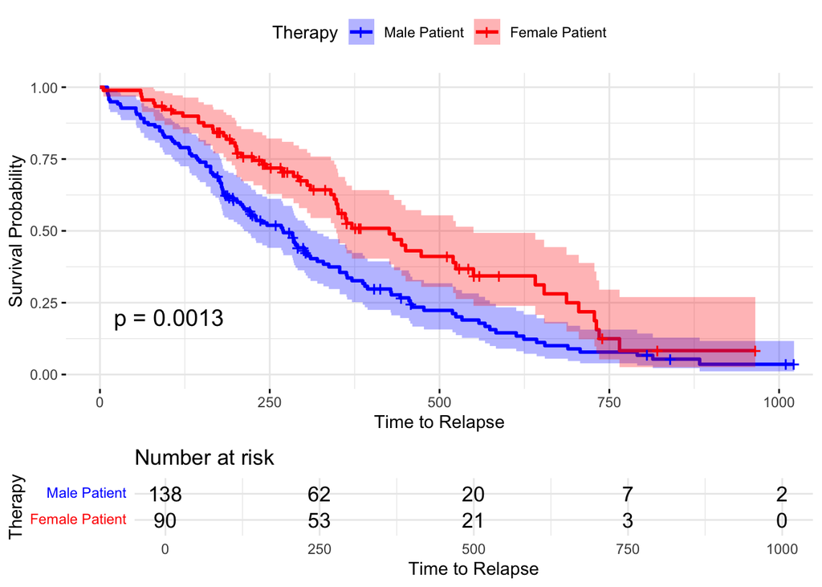

```r
# Load packages
library(survival)
library(survminer)

# Load data
aml <- read_csv("data/lung.csv")  # Load the uploaded lung.csv file

# Create survival object
# Time to relapse: time, Event occurrence: death, Treatment: x (Maintained or Nonmaintained)
fit <- survfit(Surv(time, death) ~ sex,
  data = lung)

# Plot KM curve
km_1 <- ggsurvplot(fit, data = lung,
           pval = TRUE,              # p-value (log-rank test)
           conf.int = TRUE,          # show confidence interval
           risk.table = TRUE,        # show risk table
           xlab = "Time to Relapse",
           ylab = "Survival Probability",
           legend.title = "Therapy",
           legend.labs = c("Male Patient", "Female Patient"),
           palette = c("blue", "red"),
           ggtheme = theme_minimal())
km_1
```

Findings from the Kaplan–Meier Survival Curve

・The female curve lies above the male curve.  
⇒ Compared to the male group, the female group tends to survive longer.  
・Log-rank test (p = 0.0013)  
⇒ The difference between men and women in survival time and survival probability is statistically significant.

## 2.4 Cox Proportional Hazards Model (by Gender)

### Research Question

- How does gender affect survival time in lung cancer patients?
- At the same time, we want to control for age, physician-rated performance score, caloric intake, and weight loss over the past six months.  
  ⇒ Therefore, instead of the Kaplan–Meier survival curve, we use the Cox Proportional Hazards Model.

```r
cox_model <- coxph(Surv(time, death) ~ age +
    female +
    ph.ecog +
    ph.karno +
    pat.karno +
    meal.cal +
    wt.loss,
  data = lung)
```

```r
summary(cox_model)
```

```
Call:
coxph(formula = Surv(time, death) ~ age + female + ph.ecog +
    ph.karno + pat.karno + meal.cal + wt.loss, data = lung)

  n= 168, number of events= 121
   (60 observations deleted due to missingness)

                coef  exp(coef)   se(coef)      z Pr(>|z|)
age        1.065e-02  1.011e+00  1.161e-02  0.917  0.35906
female    -5.509e-01  5.765e-01  2.008e-01 -2.743  0.00609 **
ph.ecog    7.342e-01  2.084e+00  2.233e-01  3.288  0.00101 **
ph.karno   2.246e-02  1.023e+00  1.124e-02  1.998  0.04574 *
pat.karno -1.242e-02  9.877e-01  8.054e-03 -1.542  0.12316
meal.cal   3.329e-05  1.000e+00  2.595e-04  0.128  0.89791
wt.loss   -1.433e-02  9.858e-01  7.771e-03 -1.844  0.06518 .
---
Signif. codes:  0 '***' 0.001 '**' 0.01 '*' 0.05 '.' 0.1 ' ' 1

          exp(coef) exp(-coef) lower .95 upper .95
age          1.0107     0.9894    0.9880    1.0340
female       0.5765     1.7347    0.3889    0.8545
ph.ecog      2.0838     0.4799    1.3452    3.2277
ph.karno     1.0227     0.9778    1.0004    1.0455
pat.karno    0.9877     1.0125    0.9722    1.0034
meal.cal     1.0000     1.0000    0.9995    1.0005
wt.loss      0.9858     1.0144    0.9709    1.0009

Concordance= 0.651  (se = 0.029 )
Likelihood ratio test= 28.33  on 7 df,   p=2e-04
Wald test            = 27.58  on 7 df,   p=3e-04
Score (logrank) test = 28.41  on 7 df,   p=2e-04
```

- Upper part of the output・・・log hazard ratio ⇒ cannot be directly interpreted.
- Lower part of the output・・・hazard ratio ⇒ interpretable Results for female (Hazard Ratio)

| Indicator | Value | Interpretation |
| --- | --- | --- |
| female coef | -5.509e-01 | log hazard ratio (effect of being female) |
| female exp(coef) | 0.5765 | Hazard ratio (interpretable) |
| female p-value | 0.00609 | Since it is below the 5% significance level, the difference is statistically significant |

Findings from the Cox Proportional Hazards Model (female)

##### Effect of being female (female = 1) on the risk of death

・exp(coef) = 0.5765 → The mortality risk for women is about 57.6% of that for men  
・Compared to men, women have about a 42.4% lower risk of death  
・A hazard ratio below 1 indicates lower risk  
・p-value = 0.00609 → Statistically significant

#### Results for age (Hazard Ratio)

| Indicator | Value | Interpretation |
| --- | --- | --- |
| age coef (coef) | 1.065e-02 | log hazard ratio (effect of age) |
| age exp(coef) | 1.0107 | Hazard ratio (interpretable) |
| age p-value | 0.35906 | Since it is above the 5% significance level, it is not statistically significant |

Findings from the Cox Proportional Hazards Model (age)

##### Effect of age on the risk of death

・exp(coef) = 1.0107 → Each additional year of age is estimated to increase the risk of death by about 1.07%.  
・However, this difference is not statistically significant (p-value = 0.359).  
・Therefore, in this model controlling for other variables, we cannot conclude that “higher age leads to a higher risk of death.”  
・A hazard ratio below 1 indicates reduced risk.  
・p-value = 0.35906 → Not statistically significant

# 3. Differences from Logistic Regression Analysis

#### Logistic Regression Analysis (Gender and Lung Cancer Mortality)

- Load the `lung` data

```r
library(tidyverse)
```

```r
stargazer::stargazer(lung,
  type = "html")
```

| Statistic | N | Mean | St. Dev. | Min | Max |
| --- | --- | --- | --- | --- | --- |
| inst | 227 | 11.088 | 8.303 | 1 | 33 |
| time | 228 | 305.232 | 210.646 | 5 | 1,022 |
| status | 228 | 1.724 | 0.448 | 1 | 2 |
| age | 228 | 62.447 | 9.073 | 39 | 82 |
| sex | 228 | 1.395 | 0.490 | 1 | 2 |
| ph.ecog | 227 | 0.952 | 0.718 | 0 | 3 |
| ph.karno | 227 | 81.938 | 12.328 | 50 | 100 |
| pat.karno | 225 | 79.956 | 14.623 | 30 | 100 |
| meal.cal | 181 | 928.779 | 402.175 | 96 | 2,600 |
| wt.loss | 214 | 9.832 | 13.140 | -24 | 68 |
| death | 228 | 0.724 | 0.448 | 0 | 1 |
| female | 228 | 0.395 | 0.490 | 0 | 1 |

- Draw scatter plots of death vs. age and death vs. female (using the log of the odds).
- To avoid character encoding issues, Mac users should run the following two lines:

```r
theme_set(theme_gray(base_size = 10,
                     base_family = "HiraginoSans-W3"))
```

```r
p_age <- ggplot(lung, aes(x = age, y = death)) +
  geom_jitter(size = 1,
              alpha = 1/3,
              width = 0,
              height = 0.05) +
  geom_smooth(method = "glm",
    color = "red",
    method.args = list(family = binomial(link = "logit"))) +
  labs(x = "Age",
       y = "Probability of Death")
```

```r
p_female <- ggplot(lung, aes(x = female, y = death)) +
  geom_jitter(size = 1,
              alpha = 1/3,
              width = 0.05,
              height = 0.05) +
  geom_smooth(method = "glm",
    color = "red",
    method.args = list(family = binomial(link = "logit"))) +
  labs(x = "Gender",
       y = "Probability of Death")
```

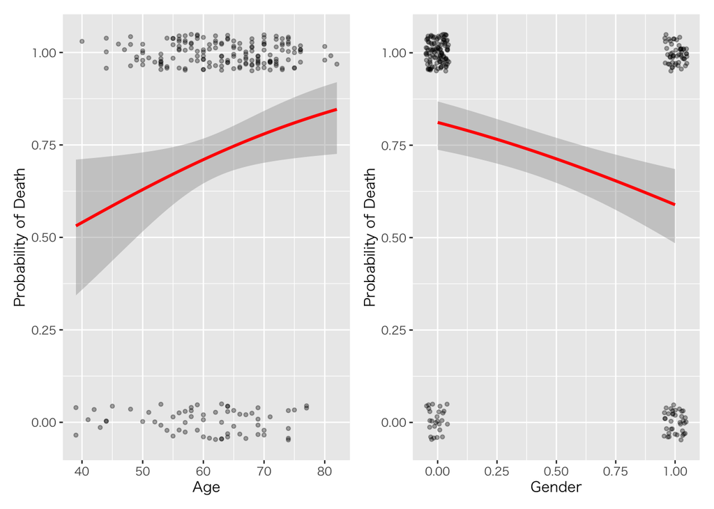

```r
p_age + p_female
```

```r
model_lung <- glm(death ~ age + female + ph.ecog + ph.karno + pat.karno + meal.cal + wt.loss,
            data = lung,
            family = binomial(link = "logit")) # 係数を「オッズの対数」に指定
```

- Use `tidy()` to check the estimation results.

```r
broom::tidy(model_lung, conf.int = TRUE)
```

```
# A tibble: 8 × 7
  term         estimate std.error statistic p.value  conf.low conf.high
  <chr>           <dbl>     <dbl>     <dbl>   <dbl>     <dbl>     <dbl>
1 (Intercept) -2.28      3.30        -0.692  0.489  -8.80       4.24
2 age          0.0210    0.0219       0.958  0.338  -0.0221     0.0643
3 female      -0.940     0.392       -2.40   0.0164 -1.72      -0.177
4 ph.ecog      1.05      0.480        2.19   0.0287  0.120      2.02
5 ph.karno     0.0293    0.0271       1.08   0.279  -0.0245     0.0827
6 pat.karno   -0.0148    0.0161      -0.914  0.361  -0.0471     0.0165
7 meal.cal     0.000250  0.000502     0.498  0.618  -0.000700   0.00129
8 wt.loss     -0.00534   0.0147      -0.364  0.716  -0.0336     0.0247
```

- However, coefficients in logistic regression cannot be interpreted in the same way as those in linear regression.

**`log-odds` are difficult to interpret → Convert them into odds ratios**

Display the results of model_lung in terms of odds ratios.

```r
tidy(model_lung,
  conf.int = TRUE,
  exponentiate = TRUE)
```

```
# A tibble: 8 × 7
  term        estimate std.error statistic p.value conf.low conf.high
  <chr>          <dbl>     <dbl>     <dbl>   <dbl>    <dbl>     <dbl>
1 (Intercept)    0.102  3.30        -0.692  0.489  0.000151    69.4
2 age            1.02   0.0219       0.958  0.338  0.978        1.07
3 female         0.390  0.392       -2.40   0.0164 0.179        0.837
4 ph.ecog        2.86   0.480        2.19   0.0287 1.13         7.51
5 ph.karno       1.03   0.0271       1.08   0.279  0.976        1.09
6 pat.karno      0.985  0.0161      -0.914  0.361  0.954        1.02
7 meal.cal       1.00   0.000502     0.498  0.618  0.999        1.00
8 wt.loss        0.995  0.0147      -0.364  0.716  0.967        1.02
```

##### Displaying Odds Ratios with a Forest Plot

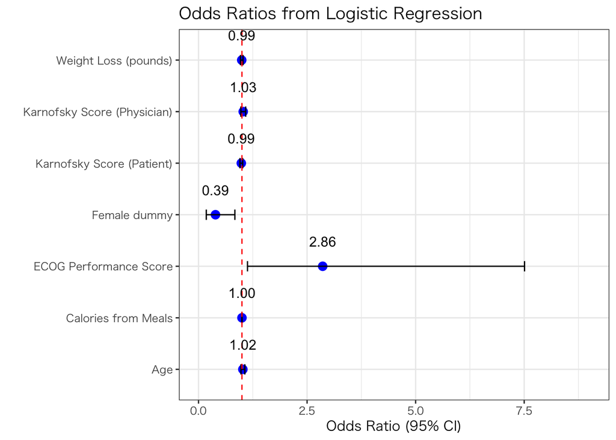

```r
# Format results (convert to odds ratios)
results <- tidy(model_lung, conf.int = TRUE, exponentiate = TRUE) %>%
  filter(term != "(Intercept)") %>%
  mutate(
    term = recode(term,
                  "female" = "Female dummy",
                  "age" = "Age",
                  "ph.ecog" = "ECOG Performance Score",
                  "ph.karno" = "Karnofsky Score (Physician)",
                  "pat.karno" = "Karnofsky Score (Patient)",
                  "meal.cal" = "Calories from Meals",
                  "wt.loss" = "Weight Loss (pounds)"),
    OR_label = sprintf("%.2f", estimate)   # Convert OR to string
  )

# Forest plot + numeric labels
ggplot(results, aes(x = estimate, y = term)) +
  geom_point(size = 3, color = "blue") +
  geom_errorbarh(aes(xmin = conf.low, xmax = conf.high), height = 0.2) +
  geom_vline(xintercept = 1, linetype = "dashed", color = "red") +
  geom_text(aes(label = OR_label), # Display OR
    hjust = 0.5,
    vjust = -2,
    size = 4) +
  labs(
    title = "Odds Ratios from Logistic Regression",
    x = "Odds Ratio (95% CI)",
    y = ""
  ) +
  theme_minimal(base_size = 14) + # Add margin so labels are not cut off
  xlim(0, max(results$conf.high) * 1.2) +
  theme_bw(base_family = "HiraKakuProN-W3")
```

#### female coefficient: 0.39 (`p-value = 0.0164`)

- Odds for females・・・$odds_{female = 1}$
- Odds for males・・・$odds_{female = 0}$

$$OddRatios =
\frac{odds_{female=1}}{odds_{female = 0}} = 0.39$$

**→ The odds for $odds_{female = 1}$ are 0.39 times the odds for $odds_{female = 0}$**

→ For females, the probability of death decreases

#### Statistical Significance

- The `p-value` for female is 0.0164.  
  → At a significance level of 0.05, we can reject the null hypothesis that “gender has no effect on the probability of death.”  
  → female has a negative effect on the probability of death, and this effect is judged to be statistically significant

**`log-odds` are difficult to interpret → Convert to probabilities**

## 3.1 Predicted Probabilities by Gender: `predict()`.

→ Useful when we want to illustrate “gender differences for a representative patient.”

- Fix age, ph.ecog, ph.karno, pat.karno, meal.cal, and wt.loss at their mean values.

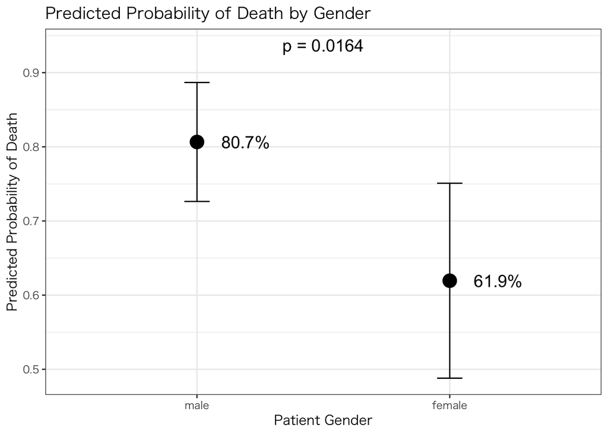

```r
library(ggplot2)
library(dplyr)

# Fix average values and set female to 0 / 1
newdata <- data.frame(
  female = c(0, 1),
  age = mean(lung$age, na.rm = TRUE),
  ph.ecog = mean(lung$ph.ecog, na.rm = TRUE),
  ph.karno = mean(lung$ph.karno, na.rm = TRUE),
  pat.karno = mean(lung$pat.karno, na.rm = TRUE),
  meal.cal = mean(lung$meal.cal, na.rm = TRUE),
  wt.loss = mean(lung$wt.loss, na.rm = TRUE)
)

# Predicted values and standard errors
pred <- predict(model_lung,
  newdata = newdata,
  type = "response",
  se.fit = TRUE)

# Data for plotting
plot_df <- newdata %>%
  mutate(
    fit = pred$fit,
    se = pred$se.fit,
    lower = fit - 1.96 * se,
    upper = fit + 1.96 * se,
    sex = factor(female, labels = c("male", "female"))
  )

# Plot: add p-value as text inside the figure
plot_prediction <- ggplot(plot_df, aes(x = sex, y = fit)) +
  geom_point(size = 5, color = "black") +
  geom_errorbar(aes(ymin = lower, ymax = upper), width = 0.1) +
  geom_text(aes(label = paste0(round(fit * 100, 1), "%")),
            hjust = -0.5, size = 5) +
  geom_text(
    data = data.frame(x = 1.5, y = max(plot_df$upper) + 0.05),
    aes(x = x, y = y, label = "p = 0.0164"),
    inherit.aes = FALSE,
    size = 5
  ) +
  labs(
    title = "Predicted Probability of Death by Gender",
    x = "Patient Gender",
    y = "Predicted Probability of Death"
  ) +
   theme_bw(base_family = "HiraKakuProN-W3")

plot_prediction
```

- When the independent variable is categorical, if the main interest of the analysis is “the effect of gender on the probability of death,” then presenting the results in this way is sufficient.
- However, if the main interest is “how the effect of being female changes depending on conditions,” it is necessary to show the conditional marginal effects for female = 0 and female = 1.

## 3.2 Predicted Probability of Death by Gender: `margins()`

#### Calculate the Average Marginal Effect (AME) to show the “effect of gender (difference)”

→ Useful when you want to show the “overall average gender difference.”  
For the categorical variable (female), compute for each observation how much the probability of death changes when switching from male → female.  
→ Take the average of these changes → this is the AME: Average Marginal Effect.  
→ This allows you to state, for example:  
“On average, women have a death probability that is X percentage points higher (or lower) than men.”  
→ The interpretation of the coefficient thus becomes much clearer.

```r
library(margins)
library(dplyr)
library(ggplot2)
```

```r
# --- Function to format p-values ---
format_p <- function(x) {
  ifelse(x < 0.001,
         "p < 0.001",
         formatC(x, format = "e", digits = 3))
}
# --- Calculation of marginal effects ---
mfx <- margins(model_lung, variables = "female")
```

```r
summary(mfx)
```

```
 factor     AME     SE       z      p   lower   upper
 female -0.1660 0.0650 -2.5543 0.0106 -0.2933 -0.0386
```

- What this AME (-0.1660) indicates:  
  ⇒ “When changing from male → female, the probability of death decreases on average by 16.6 percentage points (-0.1660).”
- p-value ≈ 0.0106 → statistically significant

Results (Comparison of Marginal Effects)  
・Understanding the “effect of gender (difference)”  
= Clarifies the “average impact of gender change on the probability of death.  
・AME = -0.1660  
→ On average, women have a death probability about 16.6 percentage points lower  
・The gender effect is statistically significant (p-value = 0.0106).

Summary of Results

#### ・Result 3.1: `predict()`

・Compares predicted probabilities for men and women by assuming an “average patient.”  
→ “Women have a probability of death that is 18.8 percentage points lower than men.”

#### ・Result 3.2: `margins()`

・Respects the conditions of each sample observation and shows the average change in probability for women (AME, with 95% CI).  
→ “On average, women have a death probability about 16.6 percentage points lower.”  
- Since logistic regression is nonlinear, it is normal for the numerical values not to match exactly.

## 3.3 Examination of Validity

#### Cox Proportional Hazards Model

| Objective | Estimate the risk of death (hazard ratio) based on “survival time.” |
| --- | --- |
| Result | Women have about a 42% lower risk of death compared to men; ph.ecog and ph.karno are significant. |
| Strength | Provides the probability of surviving up to a certain point in time (survival curve), rather than just the probability of death itself. |
| Validity | If survival data (time + censoring) are available, this is generally the most valid approach. |

#### Logistic Regression Predicted Values Plot

| Objective | Treat death as a binary outcome (0/1) and estimate “probability of death” from explanatory variables. |
| --- | --- |
| Result | Predicted probability of death: Women = 61.9%, Men = 80.7%. |
| Weakness | Treats those censored during the observation period (status = 1) as “not dead (death = 0).” |
| Validity | Inferior to the Cox proportional hazards model because it ignores survival time data. |

- Enter the data with status = 1 and death = 0.  
  → This shows that there are 63 individuals censored during the survival period (status = 1) who are treated as “not dead (death = 0).”

```r
reactable::reactable(lung,
  filterable = TRUE,  # Enable search
  defaultPageSize = 10) # Set the maximum number of rows displayed
```

|  | inst | time | status | age | sex | ph.ecog | ph.karno | pat.karno | meal.cal | wt.loss | death | female |
| --- | --- | --- | --- | --- | --- | --- | --- | --- | --- | --- | --- | --- |
| 1 | 3 | 306 | 2 | 74 | 1 | 1 | 90 | 100 | 1175 | NA | 1 | 0 |
| 2 | 3 | 455 | 2 | 68 | 1 | 0 | 90 | 90 | 1225 | 15 | 1 | 0 |
| 3 | 3 | 1010 | 1 | 56 | 1 | 0 | 90 | 90 | NA | 15 | 0 | 0 |
| 4 | 5 | 210 | 2 | 57 | 1 | 1 | 90 | 60 | 1150 | 11 | 1 | 0 |
| 5 | 1 | 883 | 2 | 60 | 1 | 0 | 100 | 90 | NA | 0 | 1 | 0 |
| 6 | 12 | 1022 | 1 | 74 | 1 | 1 | 50 | 80 | 513 | 0 | 0 | 0 |
| 7 | 7 | 310 | 2 | 68 | 2 | 2 | 70 | 60 | 384 | 10 | 1 | 1 |
| 8 | 11 | 361 | 2 | 71 | 2 | 2 | 60 | 80 | 538 | 1 | 1 | 1 |
| 9 | 1 | 218 | 2 | 53 | 1 | 1 | 70 | 80 | 825 | 16 | 1 | 0 |
| 10 | 7 | 166 | 2 | 61 | 1 | 2 | 70 | 70 | 271 | 34 | 1 | 0 |

[output cut: 218 more lines]

#### Which is more valid?

- If survival time data (time, censoring) are available:  
  → The Cox proportional hazards model is more valid.  
  Logistic regression only considers “whether death occurred by a certain time or not.”  
  → It discards time information.
- However, for papers or presentations where the goal is to produce a “visually intuitive figure showing gender differences,” logistic regression predicted probability graphs are also straightforward and useful.

**参考文献**

- Kieran Healy, DATA VISUALIZATION, Princeton, 2019
- [宋財泫 (Jaehyun Song)・矢内勇生 (Yuki Yanai)「私たちのR: ベストプラクティスの探究」](https://www.jaysong.net/RBook/)
- 浅野正彦, 矢内勇生.『Rによる計量政治学』オーム社、2018年
- 浅野正彦, 中村公亮.『初めてのRStudio』オーム社、2018年
- Winston Chang, R Graphics Cookbook, O’Reilly Media, 2012.
- Kosuke Imai, Quantitative Social Science: An Introduction, Princeton University Press, 2017